### Cluster Profiling

```python
cluster_profile = df.groupby("K_means_segments").mean()
```

```python
cluster_profile["count_in_each_segments"] = (
    df.groupby("K_means_segments")["Current Price"].count().values
)
```

```python
# let's display cluster profiles
cluster_profile.style.highlight_max(color="lightgreen", axis=0)
```

[output not shown]

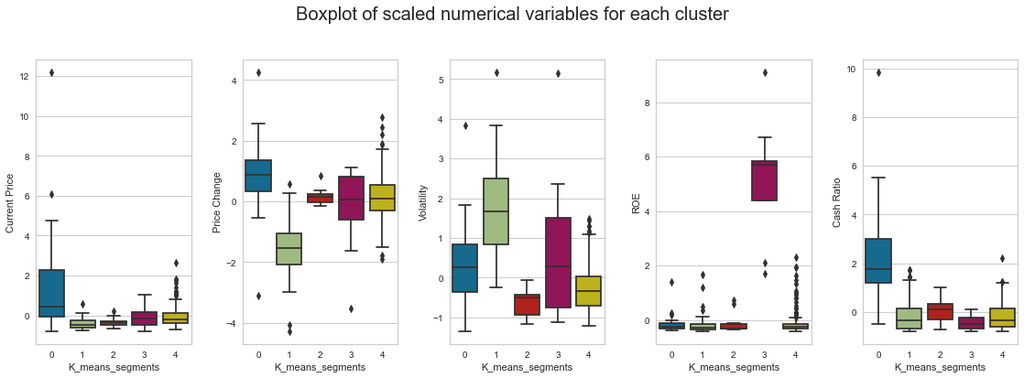

```python
fig, axes = plt.subplots(1, 5, figsize=(16, 6))
fig.suptitle("Boxplot of scaled numerical variables for each cluster", fontsize=20)
counter = 0
for ii in range(5):
    sns.boxplot(
        ax=axes[ii],
        y=subset_scaled_df[num_col[counter]],
        x=subset_scaled_df["K_means_segments"],
    )
    counter = counter + 1

fig.tight_layout(pad=2.0)
```

## K-means vs Hierarchical Clustering

```python
# list of distance metrics
distance_metrics = ["euclidean", "chebyshev", "mahalanobis", "cityblock"]

# list of linkage methods
linkage_methods = ["single", "complete", "average", "weighted"]

high_cophenet_corr = 0
high_dm_lm = [0, 0]

for dm in distance_metrics:
    for lm in linkage_methods:
        Z = linkage(subset_scaled_df, metric=dm, method=lm)
        c, coph_dists = cophenet(Z, pdist(subset_scaled_df))
        print(
            "Cophenetic correlation for {} distance and {} linkage is {}.".format(
                dm.capitalize(), lm, c
            )
        )
        if high_cophenet_corr < c:
            high_cophenet_corr = c
            high_dm_lm[0] = dm
            high_dm_lm[1] = lm
```

```
Cophenetic correlation for Euclidean distance and single linkage is 0.9245196884893159.
Cophenetic correlation for Euclidean distance and complete linkage is 0.804706102299582.
Cophenetic correlation for Euclidean distance and average linkage is 0.9453100811955032.
Cophenetic correlation for Euclidean distance and weighted linkage is 0.6627654898087273.
Cophenetic correlation for Chebyshev distance and single linkage is 0.9167442245950579.
Cophenetic correlation for Chebyshev distance and complete linkage is 0.8147175389813458.
Cophenetic correlation for Chebyshev distance and average linkage is 0.9374309398424928.
Cophenetic correlation for Chebyshev distance and weighted linkage is 0.909227804034383.
Cophenetic correlation for Mahalanobis distance and single linkage is 0.9349160370798356.
Cophenetic correlation for Mahalanobis distance and complete linkage is 0.8420923890794115.
Cophenetic correlation for Mahalanobis distance and average linkage is 0.9346420885297709.
Cophenetic correlation for Mahalanobis distance and weighted linkage is 0.8761020180095022.
Cophenetic correlation for Cityblock distance and single linkage is 0.9377940959076201.
Cophenetic correlation for Cityblock distance and complete linkage is 0.7819823728539451.
Cophenetic correlation for Cityblock distance and average linkage is 0.9278890656868077.
Cophenetic correlation for Cityblock distance and weighted linkage is 0.6579436145039212.
```

```python
print(
    "Highest cophenetic correlation is {}, which is obtained with {} distance and {} linkage.".format(
        high_cophenet_corr, high_dm_lm[0].capitalize(), high_dm_lm[1]
    )
)
```

```
Highest cophenetic correlation is 0.9453100811955032, which is obtained with Euclidean distance and average linkage.
```

### Let's explore different linkage methods with Euclidean distance only.

```python
# list of linkage methods
linkage_methods = ["single", "complete", "average", "centroid", "ward", "weighted"]

high_cophenet_corr = 0
high_dm_lm = [0, 0]

for lm in linkage_methods:
    Z = linkage(subset_scaled_df, metric="euclidean", method=lm)
    c, coph_dists = cophenet(Z, pdist(subset_scaled_df))
    print("Cophenetic correlation for {} linkage is {}.".format(lm, c))
    if high_cophenet_corr < c:
        high_cophenet_corr = c
        high_dm_lm[0] = "euclidean"
        high_dm_lm[1] = lm
```

```
Cophenetic correlation for single linkage is 0.9245196884893159.
Cophenetic correlation for complete linkage is 0.804706102299582.
Cophenetic correlation for average linkage is 0.9453100811955032.
Cophenetic correlation for centroid linkage is 0.9426384108485938.
Cophenetic correlation for ward linkage is 0.7287469098815194.
Cophenetic correlation for weighted linkage is 0.6627654898087273.
```

```python
# printing the combination of distance metric and linkage method with the highest cophenetic correlation
print(
    "Highest cophenetic correlation is {}, which is obtained with {} linkage.".format(
        high_cophenet_corr, high_dm_lm[1]
    )
)
```

```
Highest cophenetic correlation is 0.9453100811955032, which is obtained with average linkage.
```

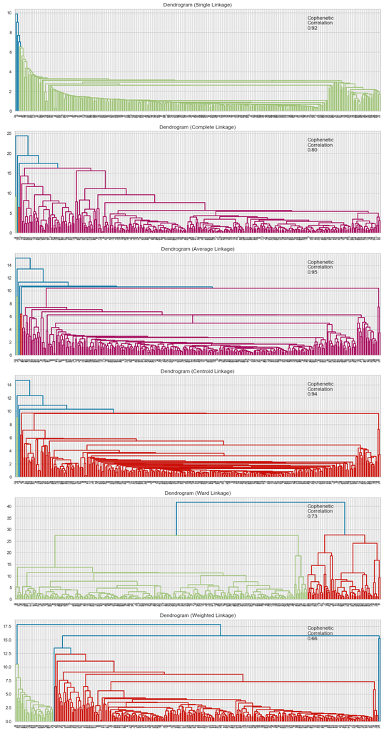

```python
# list of linkage methods
linkage_methods = ["single", "complete", "average", "centroid", "ward", "weighted"]

# lists to save results of cophenetic correlation calculation
compare_cols = ["Linkage", "Cophenetic Coefficient"]

# to create a subplot image
fig, axs = plt.subplots(len(linkage_methods), 1, figsize=(15, 30))

# We will enumerate through the list of linkage methods above
# For each linkage method, we will plot the dendrogram and calculate the cophenetic correlation
for i, method in enumerate(linkage_methods):
    Z = linkage(subset_scaled_df, metric="euclidean", method=method)

    dendrogram(Z, ax=axs[i])
    axs[i].set_title(f"Dendrogram ({method.capitalize()} Linkage)")

    coph_corr, coph_dist = cophenet(Z, pdist(subset_scaled_df))
    axs[i].annotate(
        f"Cophenetic\nCorrelation\n{coph_corr:0.2f}",
        (0.80, 0.80),
        xycoords="axes fraction",
    )
```

### Observation

```python
HCmodel = AgglomerativeClustering(n_clusters=5, affinity="euclidean", linkage="average")
HCmodel.fit(subset_scaled_df)
```

```
AgglomerativeClustering(linkage='average', n_clusters=5)
```

```python
subset_scaled_df["HC_Clusters"] = HCmodel.labels_
df["HC_Clusters"] = HCmodel.labels_
```

### Clustering Profile

```python
cluster_profile = df.groupby("HC_Clusters").mean()
```

```python
cluster_profile["count_in_each_segments"] = (
    df.groupby("HC_Clusters")["Net Income"].count().values
)
```

```python
for cl in df["HC_Clusters"].unique():
    print("In cluster {}, the following ROE are present:".format(cl))
    print(df[df["HC_Clusters"] == cl]["ROE"].unique())
    print()
```

```
In cluster 0, the following ROE are present:
[135 130  21   9  14  10  30  11   2  15   3  35 601  18  25  22   4  19
  23  52  24   8  29  82  12  38  17  20   7  27  16  44 589 463   6   1
  42  64 205  26   5  13 155  28  98  34  41  51  92 228  36  33 582 116
  68  63 263 167 103 182  61  43 244  73  45  47  32 121  40  48 596 200
 196  37  59 109  60 174  86 142]

In cluster 2, the following ROE are present:
[917 687]

In cluster 1, the following ROE are present:
[ 6 19]

In cluster 4, the following ROE are present:
[8]

In cluster 3, the following ROE are present:
[29]
```

### Insights

#### Cluster 0:

- The avearge current price change of the stocks is 78
- The price change for this particular stocks is 4.1
- The earnings per share of this stock is 2.9 per share
- The average cash ratio for the stocks is 66.8

#### Cluster 1:

- The avearge current price change of the stocks is 26
- The Volatility for this particular stocks is 1.3
- The earnings per share of this stock is 3.3 per share
- The average cash ratio for the stocks is 130

#### Cluster 2:

- The current price of the stock in this cluster is similar to those in Cluster 1, but the price change is comparatively lower (like negative)
- On average, the Estimated Shares Outstanding is 519,573,983.00 while the P/E Ration is 61

#### Cluster 3:

- The current price in the cluster is very high compared to the rest of the clusters while the price change are really low.
- The volatility for this cluster is like 1.3

### Business Recommendations

- Thus dividing stocks into groups with "similar characteristics" can help in portfolio construction to ensure we choose a collection of stocks with sufficient diversification between them.
- Investors who are more concern with downside risk and diversified portfolio might maximize their ROE
- The modern portfolio theory can be useful to investors trying to construct efficient and diversified portolio